# ZebraFinchHeatDeath(Exp1)_RNAseqAnalyses

#DESeq2 Analyses

#### Resources and Citations:

Love et al 2016 DESeq2 GenomeBiology https://bioconductor.riken.jp/packages/2.14/bioc/vignettes/DESeq2/inst/doc/DESeq2.pdf http://master.bioconductor.org/packages/release/workflows/vignettes/rnaseqGene/inst/doc/rnaseqGene.html

#### Install the DESeq2 package if you have not already

| #try http:// if https:// URLs are not supported # if (!requireNamespace(“BiocManager”, quietly = TRUE)) install.packages(“BiocManager”) BiocManager::install(“DESeq2”) |
| --- |

## Load the DESeq2 library

library(DESeq2)

##### If needed, use the Session menu to set working directory To Source File Directory

# Dataset:Deduplicated Pipeline to obtain read counts for a complete dataset of blood RNAseq sameples.

## ## Individuals used in this analyses: Baseline blood samples, from pubescent females (N=17), that either succumbed (n=10), or survived (n=7) to an acute 5 hour heat stress.

## 1.1 Input data

## Input the count data, the gene(/transcript) count matrix and labels ## this starts from with output from PrepDE.py from Ballgown folder.

```r
countdata.1 <- as.matrix(read.csv("gene_count_matrix_Dedup_BaselineHeatDeath_gene_ids_OnlyPubescent.csv", row.names="gene_id"))
dim(countdata.1)
```

```
[1] 23511    17
```

```r
head(countdata.1)
```

```
             ZF_4625_B_BL ZF_4719_B_BL ZF_4720_B_BL ZF_4737_B_BL ZF_4738_B_BL ZF_4739_B_BL ZF_4745_B_BL ZF_4761_B_BL
LOC140684310            9            5            7            2            4            0            4           47
LOC140684313           32           14           13            3            9            7            9          110
LOC140684318            0            0            8            5           29            6            4           19
LOC140680287            7            8            0            6            7            1            6           37
LOC140684329            8            2           37            7           23            8           16           46
LOC140680288            0            0           15            9           15            1            3           38
             ZF_4768_B_BL ZF_4774_B_BL ZF_4775_B_BL ZF_4784_B_BL ZF_4785_B_BL ZF_4798_B_BL ZF_4802_B_BL ZF_4810_B_BL
LOC140684310           11            4           28           30           22           12           25           33
LOC140684313           21           12           55           60           53           24           64           48
LOC140684318            0            4           14            0           40           13            8           11
LOC140680287           32           15           27           54           18           25           57           13
LOC140684329           19           12           31           31          104           21           63           58
LOC140680288           42            0           30           18           39           11           26           26
             ZF_4817_B_BL
LOC140684310           11
LOC140684313           22
LOC140684318           20
LOC140680287           18
LOC140684329           29
LOC140680288           43
```

## Input the meta data or phenotype data

# Note: The PHENO_DATA file contains information on each sample including whether they Succumb to the heat stres (Yes or No), and that this is paired-end RNAseq data.

```r
coldata.1 <-(read.table("PHENO_DATA_Baseline_DeDupHeatDeath_OnlyPubescent_n19.txt", header=TRUE, row.names=1))
dim(coldata.1)
```

```
[1] 17  2
```

```r
head(coldata.1)
```

|  | succumb | type |
| --- | --- | --- |
| ZF_4625_B_BL | No | paired-end |
| ZF_4719_B_BL | Yes | paired-end |
| ZF_4720_B_BL | No | paired-end |
| ZF_4737_B_BL | Yes | paired-end |
| ZF_4738_B_BL | No | paired-end |
| ZF_4739_B_BL | No | paired-end |

### Check all sample IDs in colData are also in CountData and match their orders

```r
all(rownames(coldata.1) %in% colnames(countdata.1))
```

```
[1] TRUE
```

```r
counts.1 <- countdata.1[, rownames(coldata.1)]
all(rownames(coldata.1) == colnames(counts.1))
```

```
[1] TRUE
```

## Create the DESEQ dataset and define the statistical model (page 6 of the manual)

```r
dds_1 <- DESeqDataSetFromMatrix(countData = countdata.1, colData=coldata.1,  design = ~succumb)
#look at it
dds_1
```

```
class: DESeqDataSet
dim: 23511 17
metadata(1): version
assays(1): counts
rownames(23511): LOC140684310 LOC140684313 ... LOC116806929 LOC140682097
rowData names(0):
colnames(17): ZF_4625_B_BL ZF_4719_B_BL ... ZF_4810_B_BL ZF_4817_B_BL
colData names(2): succumb type
```

### Prefiltering - filter lowly expressed genes, which have a reduced ability to detect differences among groups, and would increase the number of multiple testing.

## Manual - starting at 1.3.6 ## Here we perform a minimal pre-filtering to remove rows (genes) that have less than, on average across individuals, 100 reads mapped per individual. 17 individuals x 100 reads = 1700 reads. A gene must have at least 1700 reads total to be included for analysis.

```r
dds_1f <- dds_1[ rowSums(counts(dds_1)) > 1700, ]
# How many genes are left after filtering the lowest expressed genes?
dds_1f
```

```
class: DESeqDataSet
dim: 9648 17
metadata(1): version
assays(1): counts
rownames(9648): PCNP FILIP1L ... ABHD17C EEFSEC
rowData names(0):
colnames(17): ZF_4625_B_BL ZF_4719_B_BL ... ZF_4810_B_BL ZF_4817_B_BL
colData names(2): succumb type
```

# Total annotated genes in genome assembly: 23511 # filter genes with average 100 reads per sample (1700 reads) = 9648 genes

## Set factors for statistical analyses

## Succumb column in the PHENO_DATA: No is the control (survived), Yes is succumb, i.e. the “treatment group” # example: #dds$condition <- factor(dds$condition, levels=c(“untreated”,“treated”))

```r
dds_1f$condition <- factor(dds_1f$succumb, levels=c("No","Yes"))
```

#### 1.4 Differential expression analysis

```r
dds_1f <- DESeq(dds_1f)
res <- results(dds_1f)
res
```

```
log2 fold change (MLE): succumb Yes vs No
Wald test p-value: succumb Yes vs No
DataFrame with 9648 rows and 6 columns
            baseMean log2FoldChange     lfcSE      stat    pvalue      padj
           <numeric>      <numeric> <numeric> <numeric> <numeric> <numeric>
PCNP        4615.848     -0.2655619 0.1195151 -2.221994 0.0262837  0.444868
FILIP1L      129.932      0.6851822 0.3120597  2.195677 0.0281151  0.448480
TBC1D23     1319.883     -0.0963243 0.0950842 -1.013042 0.3110402  0.792426
TFG         1558.711     -0.0723538 0.1310312 -0.552188 0.5808196  0.908188
SENP7       7797.995      0.1956142 0.1676918  1.166510 0.2434083  0.750622
...              ...            ...       ...       ...       ...       ...
CCSER2       134.207       0.309067  0.299989  1.030261  0.302887  0.788197
ST6GALNAC5   325.417       1.404866  1.288653  1.090182  0.275633  0.771370
AQP9         106.250       0.293477  1.429490  0.205302  0.837336  0.977621
ABHD17C      118.150      -0.274633  0.368181 -0.745918  0.455717  0.867516
EEFSEC       114.596       0.340354  0.223804  1.520765  0.128319  0.644802
```

### Evaluate results

```r
  # We can order our results table by the smallest adjusted p value:
  resOrdered <- res[order(res$pvalue),]
  resOrdered
```

```
log2 fold change (MLE): succumb Yes vs No
Wald test p-value: succumb Yes vs No
DataFrame with 9648 rows and 6 columns
              baseMean log2FoldChange     lfcSE         stat      pvalue        padj
             <numeric>      <numeric> <numeric>    <numeric>   <numeric>   <numeric>
KCNK12         196.677       2.492489  0.448380      5.55888 2.71511e-08 0.000261954
AMOTL1         127.186       2.985397  0.612121      4.87714 1.07636e-06 0.005192361
THOC6         4308.712      -1.131395  0.236673     -4.78040 1.74942e-06 0.005626150
ELAVL3        5038.790      -0.798068  0.172716     -4.62070 3.82450e-06 0.009224690
LOC115490810   395.764       2.469206  0.549862      4.49060 7.10242e-06 0.011680234
...                ...            ...       ...          ...         ...         ...
SAP30         1391.291   -9.35085e-05  0.143176 -6.53102e-04    0.999479    0.999841
LOC140681136   130.804   -1.25241e-04  0.268137 -4.67077e-04    0.999627    0.999841
UBE4B         3527.710   -4.82663e-05  0.105005 -4.59658e-04    0.999633    0.999841
RBM15B        1787.446    5.58248e-05  0.182728  3.05507e-04    0.999756    0.999860
MRPS2          173.579   -1.51483e-05  0.305885 -4.95229e-05    0.999960    0.999960
```

# Summarize some basic tallies using the summary function the default is p<0.1.

```r
  summary(res)
```

```
out of 9648 with nonzero total read count
adjusted p-value < 0.1
LFC > 0 (up)       : 12, 0.12%
LFC < 0 (down)     : 17, 0.18%
outliers [1]       : 0, 0%
low counts [2]     : 0, 0%
(mean count < 10)
[1] see 'cooksCutoff' argument of ?results
[2] see 'independentFiltering' argument of ?results
```

# How many DEG at adjusted p-values < 0.05?

```r
  sum(res$padj < 0.05, na.rm=TRUE)
```

```
[1] 19
```

#If the adjusted p value will be a value other than 0.1, alpha should be set to that value: ## Here set to 0.05

```r
  res05 <- results(dds_1f, alpha=0.05)
  summary(res05)
```

```
out of 9648 with nonzero total read count
adjusted p-value < 0.05
LFC > 0 (up)       : 7, 0.073%
LFC < 0 (down)     : 12, 0.12%
outliers [1]       : 0, 0%
low counts [2]     : 0, 0%
(mean count < 10)
[1] see 'cooksCutoff' argument of ?results
[2] see 'independentFiltering' argument of ?results
```

```r
  sum(res05$padj < 0.05, na.rm=TRUE)
```

```
[1] 19
```

## write out the results file

```r
write.csv(as.data.frame(resOrdered),file="Submit_DGESeq_results_Dataset2-DeDup_Females_OnlyPubescent.csv")
```

### 1.5.1 MA-plot

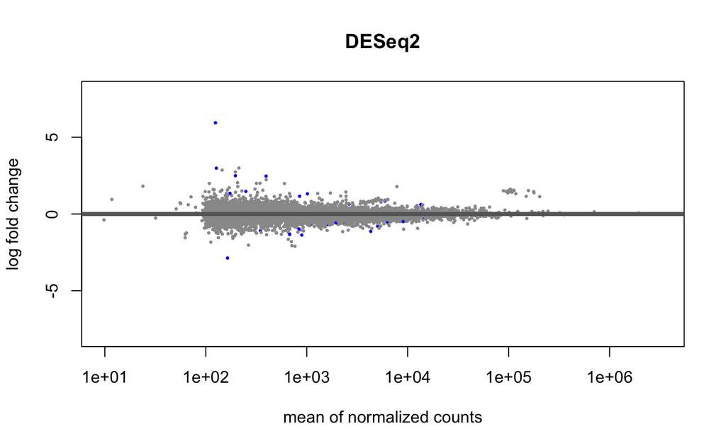

```r
plotMA(res, main="DESeq2", ylim=c(-8,8))

  #After calling plotMA, one can use the function identify to interactively detect the row number of individual genes by clicking on the plot.
  # One can then recover the gene identiers by saving the resulting indices:
idx <- identify(res$baseMean, res$log2FoldChange)
```

```r
    # after selecting a gene. You need to press escape to move on
  rownames(res)[idx]
```

```
character(0)
```

## 1.5.2 Plot counts - sanity check!

# You can select the gene to plot by rowname or by numeric index.

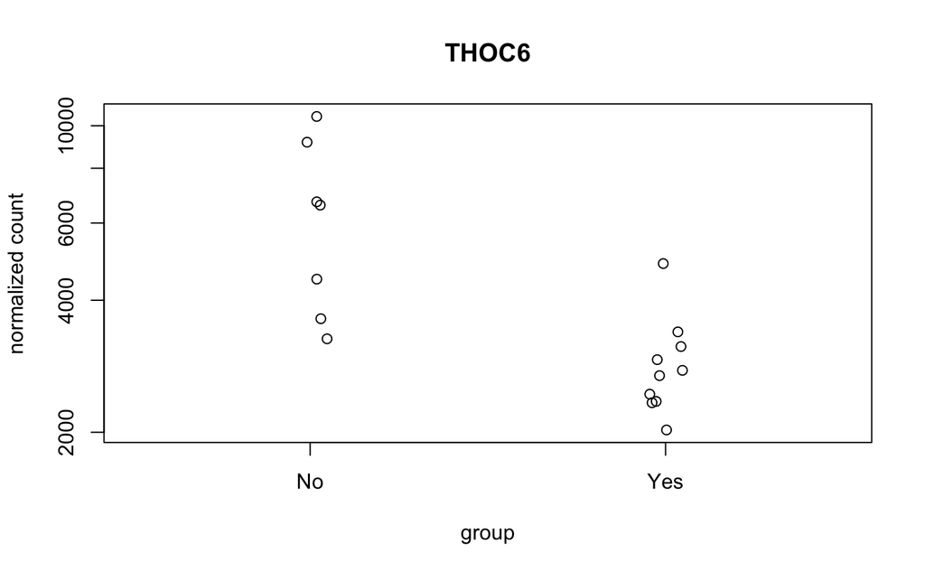

```r
## This gene has a negative logfold change, so should be downregulated in the succumb group
plotCounts(dds_1f, gene="THOC6", intgroup="succumb")
```

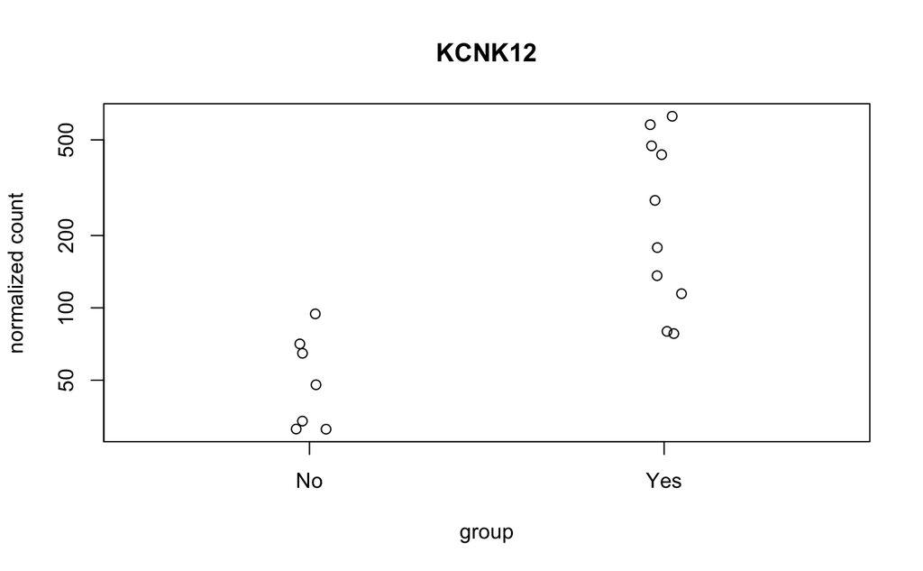

```r
## You can plot the gene with th lowest adjusted P-value.
## This gene has a postive logfold change so should be upregulated
plotCounts(dds_1f, gene=which.min(res$padj), intgroup="succumb")
```

### 2.1.2 Extracting transformed values

```r
  rld <- rlog(dds_1f)
  vsd <- varianceStabilizingTransformation(dds_1f)
  head(assay(rld), 3)
```

```
        ZF_4625_B_BL ZF_4719_B_BL ZF_4720_B_BL ZF_4737_B_BL ZF_4738_B_BL ZF_4739_B_BL ZF_4745_B_BL ZF_4761_B_BL ZF_4768_B_BL
PCNP       12.395034    12.068302    12.015743    12.201164     12.18661    12.520743    12.102414    12.110237    12.169006
FILIP1L     6.684569     6.933649     6.756145     6.899332      6.86677     6.739684     6.901559     7.173556     6.984755
TBC1D23    10.464184    10.175346    10.452288    10.363494     10.34857    10.382995    10.375868    10.291539    10.398023
        ZF_4774_B_BL ZF_4775_B_BL ZF_4784_B_BL ZF_4785_B_BL ZF_4798_B_BL ZF_4802_B_BL ZF_4810_B_BL ZF_4817_B_BL
PCNP       12.048645    12.139283    12.284443    12.264380    12.244573    12.018372    11.986459    11.883980
FILIP1L     6.629916     7.369124     6.967279     6.919739     6.898214     6.981192     7.368557     7.005637
TBC1D23    10.225575    10.411093    10.406477    10.344469    10.258504    10.469614    10.489631    10.263603
```

#### Make a heatmap of the top differentially expressed genes adjusted p-value < 0.1

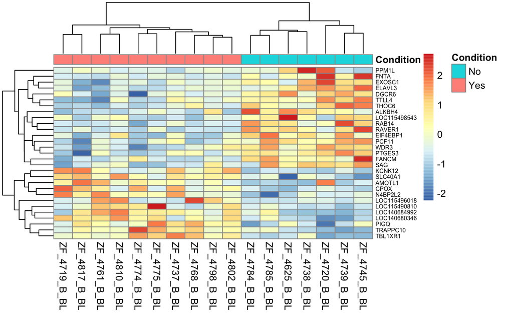

```r
library("pheatmap")
# Extract VSD matrix
vsd_mat <- assay(vsd)

# Order by p-value
res_ordered <- res[order(res$pvalue), ]

## Keep genes with adjusted p-value < 0.1
res_sig <- res[!is.na(res$padj) & res$padj < 0.1, ]
topSig_genes <- rownames(res_sig)
mat_sig_0.1 <- vsd_mat[topSig_genes, ]
###

mat_sig <- mat_sig_0.1

### Make the Heatmap
# Scale each gene (row) to z-scores
mat_scaled_sig <- t(scale(t(mat_sig)))

# Optional sample annotation
annotation_col <- data.frame(
  Condition = colData(vsd)$condition)
rownames(annotation_col) <- colnames(mat_scaled_sig)

# Heatmap
pheatmap(
  mat_scaled_sig,
  annotation_col = annotation_col,
  cluster_rows = TRUE,
  cluster_cols = TRUE,
  show_rownames = TRUE,
  show_colnames = TRUE,
  fontsize_row = 6
)
```

# Make a heatmap with adjusted p-values < 0.05 and color code for the manuscript

```r
## Keep genes with adjusted p-value < 0.1
res_sig <- res[!is.na(res$padj) & res$padj < 0.05, ]
topSig_genes <- rownames(res_sig)
mat_sig_0.05 <- vsd_mat[topSig_genes, ]
###

mat_sig <- mat_sig_0.05
mat_sig
```

```
             ZF_4625_B_BL ZF_4719_B_BL ZF_4720_B_BL ZF_4737_B_BL ZF_4738_B_BL ZF_4739_B_BL ZF_4745_B_BL ZF_4761_B_BL
WDR3            10.759953    10.499071    11.398991    10.451752    10.986073    11.249824    11.153441    10.716597
AMOTL1           7.235685     8.561499     9.654966     8.383709     7.077972     7.240481     7.637567     9.259393
N4BP2L2          9.404881    11.400628     9.672505    11.180383     9.968932     9.687352     9.887720    11.329622
TRAPPC10         9.478723     9.651255     9.176451    10.273210     9.390551     8.975241     9.134738     9.992376
KCNK12           7.887847     9.622764     7.599071     9.322497     7.743342     8.097575     7.570482     8.530912
SAG              9.241450     8.286958     9.551146     8.722621     9.608545     9.415908     9.770810     8.901438
TBL1XR1          8.993088     9.162867     8.748888     9.745208     9.198423     8.815905     8.810398     9.155012
PPM1L            9.034919     7.644174     9.941166     7.199273    10.363045     7.409786     7.156996     7.861613
DGCR6           13.187924    12.683514    13.003919    12.626877    12.555084    13.119517    12.915161    12.127995
THOC6           11.912103    11.320187    12.734802    11.818082    11.768937    13.388762    13.198141    11.132565
RAB14           12.530101    12.212702    12.374171    12.324143    12.289618    12.840071    12.593491    12.205851
ALKBH4          10.861036     9.286680    10.147383     9.668825    10.447006    10.109564     9.747226     9.528059
LOC140680346     8.109564     8.960835     7.690411     8.121694     8.023500     7.751984     8.082079     8.842481
LOC115498543    11.476690     9.641146     8.984992     9.189858     9.871438    10.421362    10.316280     9.541732
LOC115490810     8.224687     8.232946     8.128415     8.334945     7.981316     7.659876     8.119895     9.976283
PTGES3          13.161204    12.793840    13.500575    13.178849    13.344384    13.690239    13.511191    13.155192
ELAVL3          12.555978    12.157448    13.051252    12.041715    12.954743    12.815039    13.265112    11.693134
RAVER1          11.598026    11.072299    11.117964    10.981836    11.364166    11.529078    11.918561    11.043607
FNTA            10.066282     9.500288    11.637860     9.724618     9.884836    10.197090    11.597451     9.350406
             ZF_4768_B_BL ZF_4774_B_BL ZF_4775_B_BL ZF_4784_B_BL ZF_4785_B_BL ZF_4798_B_BL ZF_4802_B_BL ZF_4810_B_BL
WDR3            10.678764    10.038763    10.375029    11.069969    11.414525    10.811555    11.046857    10.551280
AMOTL1           7.787019     8.632482     8.200737     7.237003     7.375311     8.259673     7.678642     8.043416
N4BP2L2          9.906114    10.384930    10.221789     9.235184     8.556054     9.932848     9.929148    10.186156
TRAPPC10        10.599334    11.329484    10.791314     9.804581     9.938656     9.869966    10.122680     9.941658
KCNK12           8.334222     7.988529     8.218513     7.569853     7.934809     8.905920     9.409091     8.000450
SAG              8.692320     8.400525     8.446141     8.680517     9.778547     9.327940     8.821010     9.024440
TBL1XR1          9.585669     9.659841     9.538761     8.972145     8.892661     9.240520     9.390443     9.213689
PPM1L            7.763539     7.630305     7.654297     7.860312     7.817506     7.900056     7.728726     7.525577
DGCR6           12.427379    11.862830    12.514367    12.758456    12.857451    12.547871    12.477815    12.472176
THOC6           12.308864    11.329484    11.509132    12.759096    12.196364    11.714082    11.546155    11.621344
RAB14           12.170360    12.029904    12.207342    12.701091    12.557361    12.233262    12.210384    12.275883
ALKBH4           9.437848     9.681035     9.932377    11.110801    10.229451    10.393879     9.352362     9.449838
LOC140680346     8.605743     8.614474     8.843266     8.168203     8.496979     8.350520     8.874746     9.151714
LOC115498543     8.796086     9.012193     8.904240     9.755803    10.023343     9.439623     9.262557     9.741777
LOC115490810     7.992629     9.475589    11.471634     8.255906     8.651043     8.694319     9.735631     9.739985
PTGES3          13.185601    12.768924    12.879822    13.361823    13.407211    12.902770    13.149868    12.881722
ELAVL3          12.189427    11.863530    11.872057    12.086800    12.213678    12.134676    12.193225    12.124462
RAVER1          11.100234    10.995188    11.243377    11.725022    11.460312    11.069529    11.054958    11.128244
FNTA             9.454469     9.486808     9.709050    10.118604     9.456924     9.620228     9.394193     9.738191
             ZF_4817_B_BL
WDR3            10.143683
AMOTL1           9.727403
N4BP2L2         10.487172
TRAPPC10        10.182504
KCNK12           9.710759
SAG              8.702761
TBL1XR1          9.228516
PPM1L            8.051884
DGCR6           12.425074
THOC6           11.379574
RAB14           12.173892
ALKBH4           9.491715
LOC140680346     8.748338
LOC115498543     8.915798
LOC115490810     8.727509
PTGES3          12.434813
ELAVL3          11.544759
RAVER1          11.211078
FNTA             9.451904
```

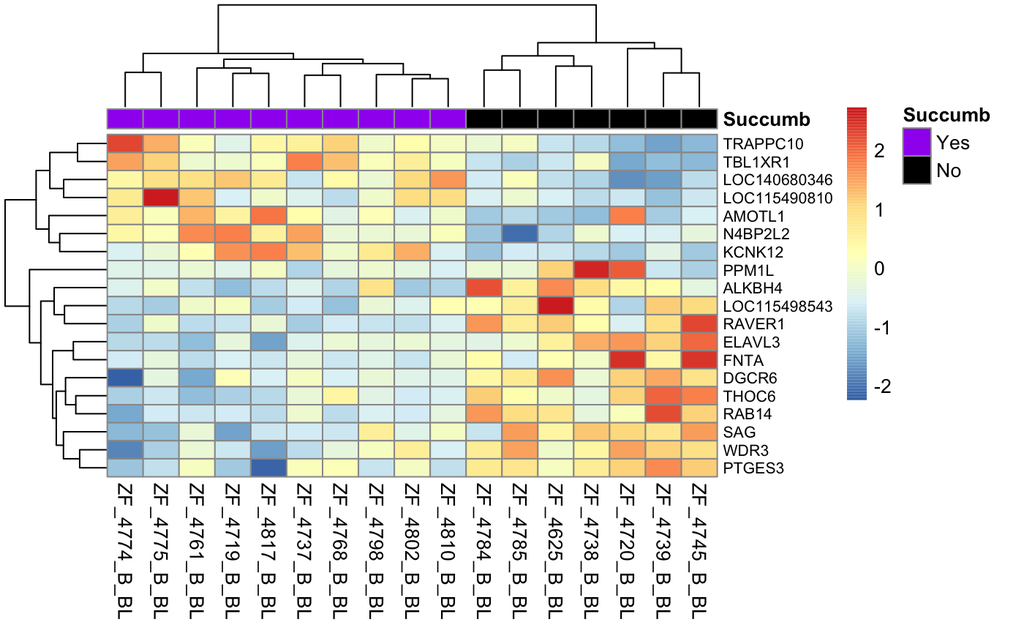

```r
### Make the Heatmap
# Scale each gene (row) to z-scores
mat_scaled_sig <- t(scale(t(mat_sig)))

# Optional sample annotation
annotation_col <- data.frame(
  Condition = colData(vsd)$condition)
rownames(annotation_col) <- colnames(mat_scaled_sig)

annotation_colors <- list(
  Succumb = c(
    Yes = "purple",
    No = "black"
  )
)

colnames(annotation_col)[colnames(annotation_col) == "Condition"] <- "Succumb"

# Heatmap
pheatmap(
  mat_scaled_sig,
  annotation_col = annotation_col,
  annotation_colors = annotation_colors,
  cluster_rows = TRUE,
  cluster_cols = TRUE,
  show_rownames = TRUE,
  show_colnames = TRUE,
  fontsize_row = 8
)
```

### Make a PCA from top genes with adjusted p-value < 0.05

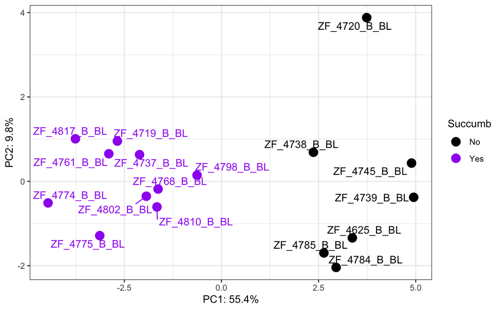

```r
library(ggplot2)
library(ggrepel)

# PCA expects samples in rows and genes in columns
pca <- prcomp(t(mat_sig_0.05), scale. = TRUE)


# Percent variance explained
percentVar <- pca$sdev^2 / sum(pca$sdev^2)
# Create plotting dataframe
pca_df <- data.frame(
  PC1 = pca$x[,1],
  PC2 = pca$x[,2],
  condition = colData(vsd)$condition,
  sample = colnames(vsd)
)


ggplot(pca_df, aes(PC1, PC2, color = condition)) +
  geom_point(size = 4) +
  xlab(paste0("PC1: ", round(percentVar[1] * 100, 1), "%")) +
  ylab(paste0("PC2: ", round(percentVar[2] * 100, 1), "%")) +
  geom_text_repel(aes(label = sample)) +
  scale_color_manual(values = c("Yes" = "purple",
                                "No" = "black")) +
  labs(color = "Succumb") +
  theme_bw()
```

```r
#ggplot(pca_df, aes(PC1, PC2, color = condition)) +
 # geom_point(size = 4) +
#  xlab(paste0("PC1: ", round(percentVar[1] * 100, 1), "%")) +
 # ylab(paste0("PC2: ", round(percentVar[2] * 100, 1), "%")) +
  #geom_text_repel(aes(label = sample))  +
  #theme_bw()
```

## Rename first column so it matches “gene_id” in annotation file

```r
names(resOrdered)[1]<- "gene_id"
```

#### Make a list of all the genes ranked by the p-value and logfold change, that can be brought into GSEA

## example aa <- within(resOrdered, z <- x + y - 2)

```r
DGE_Rank <-  within(resOrdered, rank <- sign(log2FoldChange) * -log10(pvalue))
DGE_Rank
```

```
log2 fold change (MLE): succumb Yes vs No
Wald test p-value: succumb Yes vs No
DataFrame with 9648 rows and 7 columns
               gene_id log2FoldChange     lfcSE         stat      pvalue        padj         rank
             <numeric>      <numeric> <numeric>    <numeric>   <numeric>   <numeric>    <numeric>
KCNK12         196.677       2.492489  0.448380      5.55888 2.71511e-08 0.000261954      7.56621
AMOTL1         127.186       2.985397  0.612121      4.87714 1.07636e-06 0.005192361      5.96804
THOC6         4308.712      -1.131395  0.236673     -4.78040 1.74942e-06 0.005626150     -5.75710
ELAVL3        5038.790      -0.798068  0.172716     -4.62070 3.82450e-06 0.009224690     -5.41743
LOC115490810   395.764       2.469206  0.549862      4.49060 7.10242e-06 0.011680234      5.14859
...                ...            ...       ...          ...         ...         ...          ...
SAP30         1391.291   -9.35085e-05  0.143176 -6.53102e-04    0.999479    0.999841 -2.26370e-04
LOC140681136   130.804   -1.25241e-04  0.268137 -4.67077e-04    0.999627    0.999841 -1.61880e-04
UBE4B         3527.710   -4.82663e-05  0.105005 -4.59658e-04    0.999633    0.999841 -1.59308e-04
RBM15B        1787.446    5.58248e-05  0.182728  3.05507e-04    0.999756    0.999860  1.05876e-04
MRPS2          173.579   -1.51483e-05  0.305885 -4.95229e-05    0.999960    0.999960 -1.71609e-05
```

#subset the results so only Gene Name and rank

```r
DGErank = subset(DGE_Rank, select = c(rank) )
DGErank
```

```
DataFrame with 9648 rows and 1 column
                     rank
                <numeric>
KCNK12            7.56621
AMOTL1            5.96804
THOC6            -5.75710
ELAVL3           -5.41743
LOC115490810      5.14859
...                   ...
SAP30        -2.26370e-04
LOC140681136 -1.61880e-04
UBE4B        -1.59308e-04
RBM15B        1.05876e-04
MRPS2        -1.71609e-05
```

#remove any genes that don’t ahve a name

```r
DGErank_withName <- na.omit(DGErank)
DGErank_withName
```

```
DataFrame with 9648 rows and 1 column
                     rank
                <numeric>
KCNK12            7.56621
AMOTL1            5.96804
THOC6            -5.75710
ELAVL3           -5.41743
LOC115490810      5.14859
...                   ...
SAP30        -2.26370e-04
LOC140681136 -1.61880e-04
UBE4B        -1.59308e-04
RBM15B        1.05876e-04
MRPS2        -1.71609e-05
```

```r
dim(DGErank_withName)
```

```
[1] 9648    1
```

## Write out the file with the ranked list for GSEA - will use the GUI interface.

```r
write.table(as.data.frame(DGErank_withName), file="DeDup_DGErankName_OnlyPubescent.rnk", quote=FALSE, row.names=TRUE, sep = "\t")
```

#### Get the normalized expression DATA, incase need it.

```r
nt <- normTransform(dds_1f) # defaults to log2(x+1)
head(assay(nt))
```

```
        ZF_4625_B_BL ZF_4719_B_BL ZF_4720_B_BL ZF_4737_B_BL ZF_4738_B_BL ZF_4739_B_BL ZF_4745_B_BL ZF_4761_B_BL ZF_4768_B_BL
PCNP       12.519951    12.020534    11.938094    12.226221    12.203857     12.70654    12.073713    12.085877    12.176781
FILIP1L     5.957645     6.918089     6.271795     6.804421     6.693209      6.19848     6.812145     7.613419     7.080069
TBC1D23    10.533144    10.046182    10.513633    10.366863    10.341999     10.39930    10.387435    10.246239    10.424207
TFG        10.539086    10.907688    10.398944    10.431823    10.328535     10.57577    11.052594    10.566705    10.786695
SENP7      13.389567    12.987509    12.100763    12.645510    12.744050     12.72980    12.472686    13.185179    13.361893
TRMT10C     9.871243     9.972253    10.051521    10.566031    10.051356     10.43468    10.265697     9.689625     9.554711
        ZF_4774_B_BL ZF_4775_B_BL ZF_4784_B_BL ZF_4785_B_BL ZF_4798_B_BL ZF_4802_B_BL ZF_4810_B_BL ZF_4817_B_BL
PCNP       11.989805    12.130889    12.353262    12.322802    12.292617    11.942277    11.891876    11.728371
FILIP1L     5.688387     8.096616     7.025104     6.872700     6.801072     7.068345     8.095361     7.143040
TBC1D23    10.133675    10.445769    10.438091    10.335142    10.190121    10.541980    10.574869    10.198794
TFG        10.647283    10.656937    10.820910    10.693459    10.314327    10.209169    10.669462    10.436997
SENP7      12.752912    13.105318    12.938557    12.963055    13.051312    12.830567    12.627262    13.302319
TRMT10C     9.879452     9.511775    10.014306     8.937131     9.783740    10.011074    10.050795     9.906172
```

# make it a new dataframe

```r
NormTransExp<-assay(nt)
summary(NormTransExp)
```

```
  ZF_4625_B_BL     ZF_4719_B_BL     ZF_4720_B_BL     ZF_4737_B_BL     ZF_4738_B_BL     ZF_4739_B_BL     ZF_4745_B_BL
 Min.   : 0.000   Min.   : 0.000   Min.   : 0.000   Min.   : 0.000   Min.   : 0.000   Min.   : 0.000   Min.   : 0.000
 1st Qu.: 7.946   1st Qu.: 8.086   1st Qu.: 8.273   1st Qu.: 8.019   1st Qu.: 8.084   1st Qu.: 7.854   1st Qu.: 8.058
 Median : 9.621   Median : 9.635   Median : 9.861   Median : 9.763   Median : 9.712   Median : 9.593   Median : 9.768
 Mean   : 9.787   Mean   : 9.816   Mean   : 9.875   Mean   : 9.802   Mean   : 9.825   Mean   : 9.748   Mean   : 9.807
 3rd Qu.:11.452   3rd Qu.:11.361   3rd Qu.:11.443   3rd Qu.:11.462   3rd Qu.:11.426   3rd Qu.:11.472   3rd Qu.:11.442
 Max.   :22.081   Max.   :21.757   Max.   :21.232   Max.   :22.147   Max.   :22.032   Max.   :22.012   Max.   :21.532
  ZF_4761_B_BL     ZF_4768_B_BL     ZF_4774_B_BL     ZF_4775_B_BL     ZF_4784_B_BL     ZF_4785_B_BL     ZF_4798_B_BL
 Min.   : 0.000   Min.   : 0.000   Min.   : 0.000   Min.   : 0.000   Min.   : 0.000   Min.   : 0.000   Min.   : 0.000
 1st Qu.: 8.116   1st Qu.: 8.025   1st Qu.: 8.254   1st Qu.: 8.018   1st Qu.: 8.103   1st Qu.: 8.020   1st Qu.: 8.050
 Median : 9.625   Median : 9.588   Median : 9.736   Median : 9.580   Median : 9.642   Median : 9.567   Median : 9.628
 Mean   : 9.821   Mean   : 9.800   Mean   : 9.850   Mean   : 9.801   Mean   : 9.821   Mean   : 9.806   Mean   : 9.809
 3rd Qu.:11.324   3rd Qu.:11.378   3rd Qu.:11.332   3rd Qu.:11.410   3rd Qu.:11.365   3rd Qu.:11.401   3rd Qu.:11.387
 Max.   :21.111   Max.   :21.959   Max.   :21.730   Max.   :21.625   Max.   :21.065   Max.   :21.274   Max.   :21.670
  ZF_4802_B_BL     ZF_4810_B_BL     ZF_4817_B_BL
 Min.   : 0.000   Min.   : 0.000   Min.   : 0.000
 1st Qu.: 8.081   1st Qu.: 8.139   1st Qu.: 8.051
 Median : 9.644   Median : 9.666   Median : 9.642
 Mean   : 9.834   Mean   : 9.860   Mean   : 9.826
 3rd Qu.:11.372   3rd Qu.:11.372   3rd Qu.:11.416
 Max.   :21.516   Max.   :21.144   Max.   :21.502
```

```r
head(NormTransExp)
```

```
        ZF_4625_B_BL ZF_4719_B_BL ZF_4720_B_BL ZF_4737_B_BL ZF_4738_B_BL ZF_4739_B_BL ZF_4745_B_BL ZF_4761_B_BL ZF_4768_B_BL
PCNP       12.519951    12.020534    11.938094    12.226221    12.203857     12.70654    12.073713    12.085877    12.176781
FILIP1L     5.957645     6.918089     6.271795     6.804421     6.693209      6.19848     6.812145     7.613419     7.080069
TBC1D23    10.533144    10.046182    10.513633    10.366863    10.341999     10.39930    10.387435    10.246239    10.424207
TFG        10.539086    10.907688    10.398944    10.431823    10.328535     10.57577    11.052594    10.566705    10.786695
SENP7      13.389567    12.987509    12.100763    12.645510    12.744050     12.72980    12.472686    13.185179    13.361893
TRMT10C     9.871243     9.972253    10.051521    10.566031    10.051356     10.43468    10.265697     9.689625     9.554711
        ZF_4774_B_BL ZF_4775_B_BL ZF_4784_B_BL ZF_4785_B_BL ZF_4798_B_BL ZF_4802_B_BL ZF_4810_B_BL ZF_4817_B_BL
PCNP       11.989805    12.130889    12.353262    12.322802    12.292617    11.942277    11.891876    11.728371
FILIP1L     5.688387     8.096616     7.025104     6.872700     6.801072     7.068345     8.095361     7.143040
TBC1D23    10.133675    10.445769    10.438091    10.335142    10.190121    10.541980    10.574869    10.198794
TFG        10.647283    10.656937    10.820910    10.693459    10.314327    10.209169    10.669462    10.436997
SENP7      12.752912    13.105318    12.938557    12.963055    13.051312    12.830567    12.627262    13.302319
TRMT10C     9.879452     9.511775    10.014306     8.937131     9.783740    10.011074    10.050795     9.906172
```

# Write the Normalized Transfored Data

```r
write.table(as.data.frame(NormTransExp), file="Dedup_NormTransExp_OnlyPubescent.txt", quote=FALSE, row.names=TRUE, sep = "\t")
```

#### GSEA was conducted on the GUI interface.

##The enriched pathways were organized in to the Hallmarks.csv file for plotting. ## We used AI to troubleshoot this section of code.

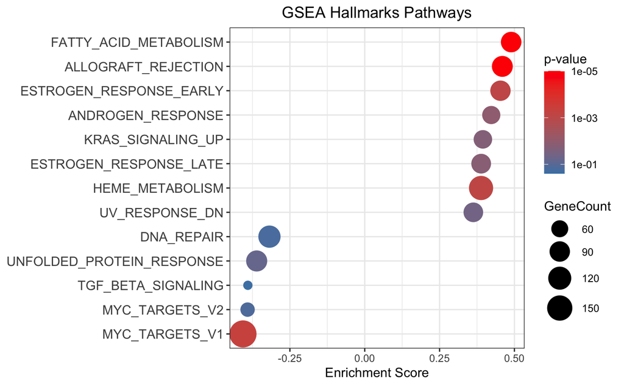

```r
library(ggplot2)
Hallmark <- read.csv("Hallmarks.csv")

ggplot(Hallmark,
       aes(x = EnrichmentScore,
           y = reorder(Name, EnrichmentScore),
           size = GeneCount,
           color = NOM_pvalue)) +

  geom_point() +

  #facet_grid(. ~ Direction) +

  scale_color_gradient(
    low = "red",
    high = "steelblue",
    trans = "log10",
    name = "p-value",
    limits = c(0.00001, 0.25),
    guide = guide_colorbar(reverse = TRUE)
  ) +

  scale_size(range = c(3,10)) +

  labs(
    title = "GSEA Hallmarks Pathways",
    x = "Enrichment Score",
    y = NULL
  ) +

  theme_bw() +

  theme(
    plot.title = element_text(hjust = 0.5),
    strip.background = element_rect(fill = "grey85"),
    strip.text = element_text(face = "bold"),
    axis.text.y = element_text(size = 11)
  )
```